# Discrete time models

Everything ctsem does in continuous time it can also do in discrete time, where the model describes change from one occasion to the next: vector autoregressions, cross-lagged panel models with random intercepts, factor models for the processes, and checks of the fit. A discrete time model treats the occasions as equally spaced, so it suits data collected at a fixed interval, and its parameters refer to that interval. Why continuous time says more about the choice between the two.

```r
library(ctsem)
library(ggplot2)
```

# Data

The example follows 100 workers through their first ten weeks in a new job. Stress is measured by two questionnaire items, `Stress` and `Stress2`, and the quality of each worker’s output by `Quality`. The questions are how stress and quality change after starting the job, whether one affects the other, and how people differ in where they start and where they settle.

The data are simulated from a discrete time model in which stress lowers the next week’s quality, workers start stressed and settle at their own long run levels, and those with a higher long run level of stress have a lower long run level of quality:

```r
set.seed(2)
gm <- ctModel(type = 'dt',
  manifestNames = c('Stress', 'Stress2', 'Quality'),
  latentNames = c('stress', 'quality'),
  LAMBDA = matrix(c(
    1, 0,
    0.8, 0,
    0, 1), 3, 2, byrow = TRUE),
  DRIFT = matrix(c(
    0.6, 0,
    -0.3, 0.7), 2, 2, byrow = TRUE),
  DIFFUSION = diag(c(0.8, 0.5)),
  CINT = c('cint_stress', 'cint_quality'),
  T0MEANS = c('t0_stress', 't0_quality'),
  MANIFESTMEANS = c(0, 1, 0),
  MANIFESTVAR = diag(0.5, 3))
dat <- data.frame(ctGenerate(gm, n = 100, Tpoints = 10, backend = 'julia',
  values = list(
    popmeans = c(cint_stress = 1, cint_quality = 1.5,
      t0_stress = 4, t0_quality = 0),
    popsd = c(cint_stress = 0.4, cint_quality = 0.4,
      t0_stress = 1, t0_quality = 1),
    rawpopcorr = c(cint_stress__cint_quality = -0.6))))
head(dat)
```

```
#>   id time   Stress  Stress2    Quality
#> 1  1    0 2.484161 3.730844  0.7584292
#> 2  1    1 2.547169 2.484342 -0.4371261
#> 3  1    2 3.319269 4.923508 -0.2389048
#> 4  1    3 3.704649 4.188055 -1.9908365
#> 5  1    4 5.209853 5.103995 -1.3112271
#> 6  1    5 4.885877 4.798512 -2.3627164
```

# A bivariate model

The first model uses one indicator per process, leaving out `Stress2`. In discrete time the `DRIFT` matrix holds the autoregressions on its diagonal and the cross-lagged effects off it. `DRIFT[2, 1]` is the effect of this week’s stress on next week’s quality. The measurement intercepts (`MANIFESTMEANS`) are each person’s long run levels, since the processes return to zero, and they vary over people, as do the starting values (`T0MEANS`). Most of this is ctsem’s default, but the model is written out in full here to show each part:

```r
model <- ctModel(type = 'dt',
  manifestNames = c('Stress', 'Quality'),
  latentNames = c('stress', 'quality'),
  LAMBDA = diag(2),
  T0MEANS = c('t0_stress', 't0_quality'),
  MANIFESTMEANS = c('mi_stress, indvarying = TRUE',
    'mi_quality, indvarying = TRUE'),
  MANIFESTVAR = c(
    'merr_stress', 0,
    0, 'merr_quality'),
  DRIFT = c(
    'a11', 'a12',
    'a21', 'a22'),
  DIFFUSION = c(
    'diff11', 0,
    'diff21', 'diff22'),
  CINT = 0)
```

A vector given for a matrix fills it row by row. `DIFFUSION` and `MANIFESTVAR` hold standard deviations on their diagonals and correlation parameters below them.

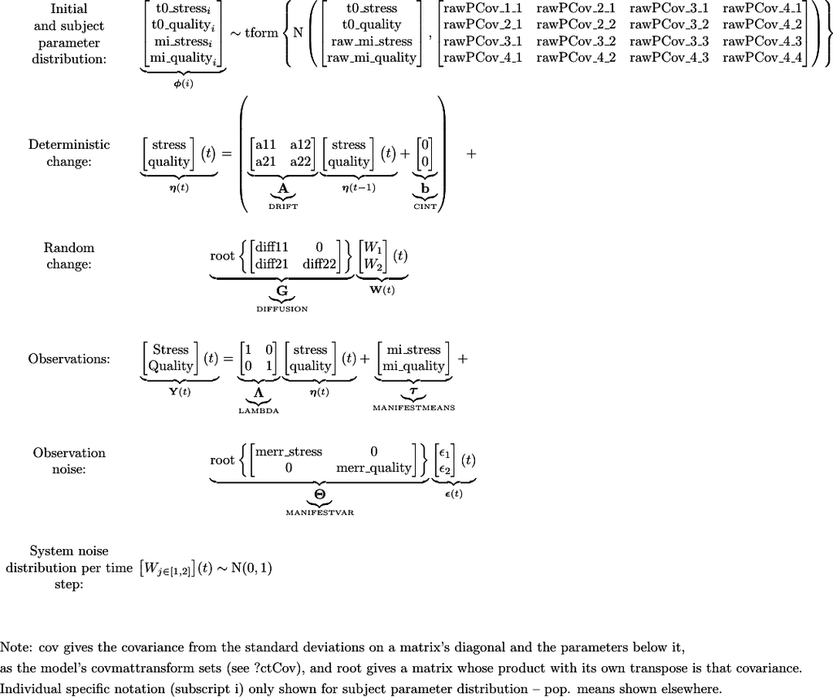

```r
fit <- ctFit(dat, model, cores = 2)
s <- summary(fit)
s$popmeans
```

```
#>                mean    sd   2.5%    50%  97.5%   mode
#> t0_stress     1.180 0.155  0.882  1.186  1.487  1.173
#> t0_quality   -1.878 0.262 -2.357 -1.880 -1.391 -1.855
#> a11           0.656 0.060  0.522  0.659  0.761  0.657
#> a12           0.078 0.038  0.001  0.078  0.148  0.077
#> a21          -0.300 0.036 -0.370 -0.301 -0.228 -0.301
#> a22           0.684 0.028  0.630  0.683  0.737  0.683
#> diff11        0.762 0.070  0.642  0.758  0.908  0.762
#> diff21        0.019 0.075 -0.126  0.016  0.168  0.022
#> diff22        0.503 0.047  0.420  0.500  0.602  0.501
#> merr_stress   0.532 0.073  0.399  0.530  0.692  0.525
#> merr_quality  0.503 0.036  0.435  0.504  0.574  0.502
#> mi_stress     3.015 0.134  2.750  3.011  3.270  3.019
#> mi_quality    1.873 0.238  1.416  1.874  2.324  1.854
```

`a21`, the effect of stress on next week’s quality, is -0.30, as generated, with an interval well away from zero. `a12`, the effect of quality on stress, was generated as 0 and is estimated at 0.08, with an interval that only just excludes zero. With a 95% interval for each of several parameters, one now and then lands just beside its true value. `rawpopcorr` holds the correlations of the random effects:

```r
s$rawpopcorr
```

```
#>                          mean    sd   2.5%    50%  97.5%   mode       z
#> t0_quality__t0_stress  -0.583 0.092 -0.740 -0.592 -0.391 -0.598  -6.362
#> mi_stress__t0_stress   -0.615 0.090 -0.770 -0.623 -0.426 -0.627  -6.826
#> mi_quality__t0_stress   0.615 0.083  0.442  0.619  0.763  0.628   7.394
#> mi_stress__t0_quality   0.773 0.070  0.614  0.782  0.881  0.787  10.974
#> mi_quality__t0_quality -0.880 0.029 -0.927 -0.883 -0.818 -0.884 -30.722
#> mi_quality__mi_stress  -0.847 0.052 -0.925 -0.856 -0.717 -0.858 -16.144
```

Those with a higher long run level of stress (`mi_stress`) have a lower long run level of quality (`mi_quality`). The generating values imply a correlation of about -0.86 between the two.

The starting values `t0_stress` and `t0_quality` are deviations from each person’s long run level, because the processes return to zero and the measurement intercepts hold the long run levels. The data were generated with starting levels unrelated to the long run levels, so someone with a higher long run level starts further below it, and each starting value correlates negatively with its own long run level.

# Predictions and effects over time

`ctPredict()` gives the predicted values for each person from their earlier observations (`yprior`), and the smoothed values from all of them (`ysmooth`):

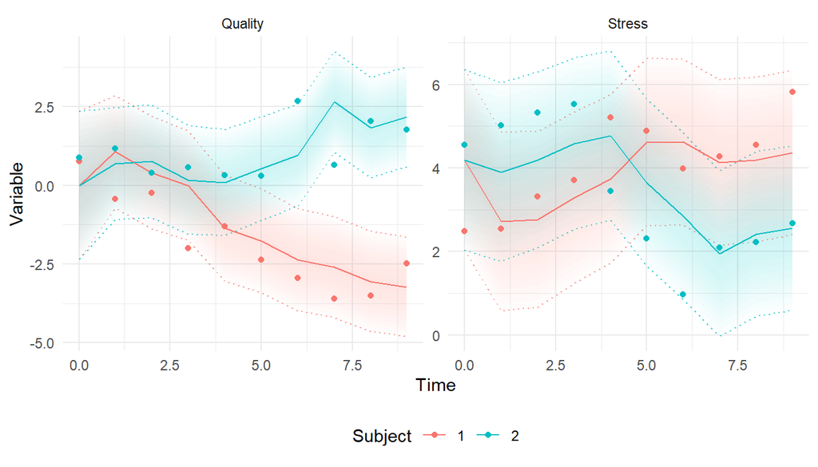

```r
ctPredict(fit, subjects = 1:2, plot = TRUE, kalmanvec = c('y', 'yprior'))
```

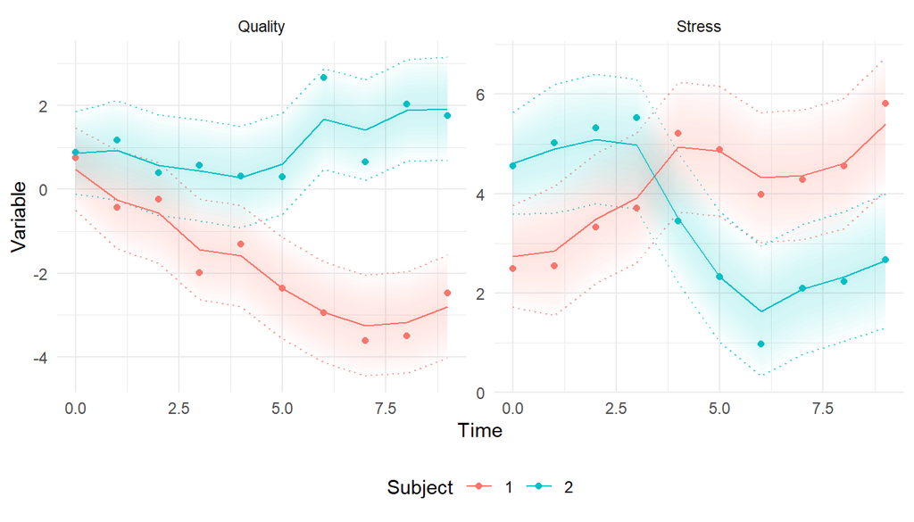

```r
ctPredict(fit, subjects = 1:2, plot = TRUE, kalmanvec = c('y', 'ysmooth'))
```

With `removeObs = TRUE` the predictions use no observations at all, only the population parameters. This is the average course of a new worker:

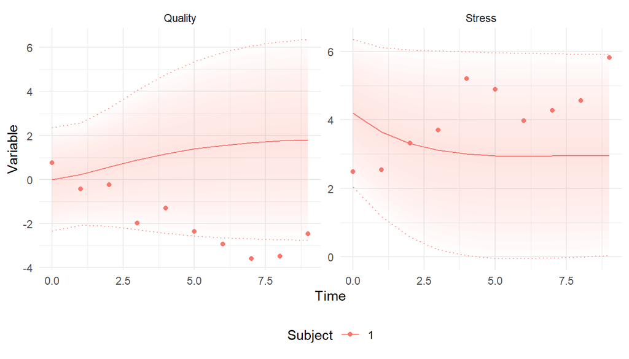

```r
ctPredict(fit, subjects = 1, plot = TRUE, kalmanvec = c('y', 'yprior'),
  removeObs = TRUE)
```

`ctDiscretePars()` shows the effect of a change in one process on each process, one or more weeks later. It is still a first order model. A change this week affects next week directly, and later weeks through the weeks in between.

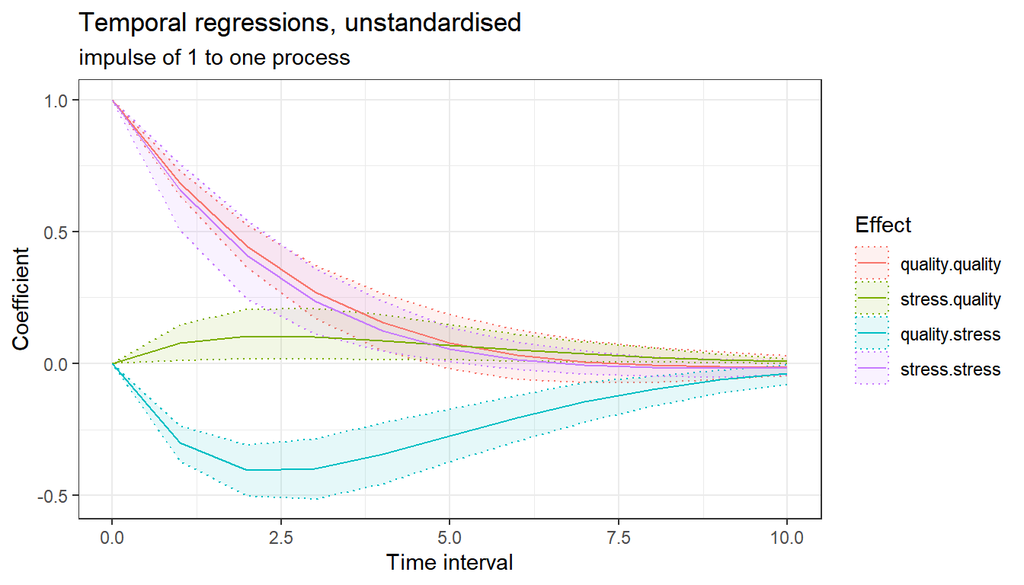

```r
ctDiscretePars(fit, plot = TRUE)
```

# Checking the model

`ctFitCheckCov()` compares the correlations in the data, within and across weeks, with those the model implies:

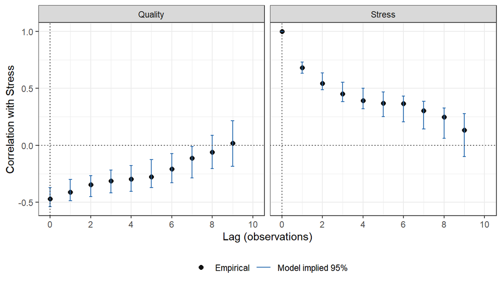

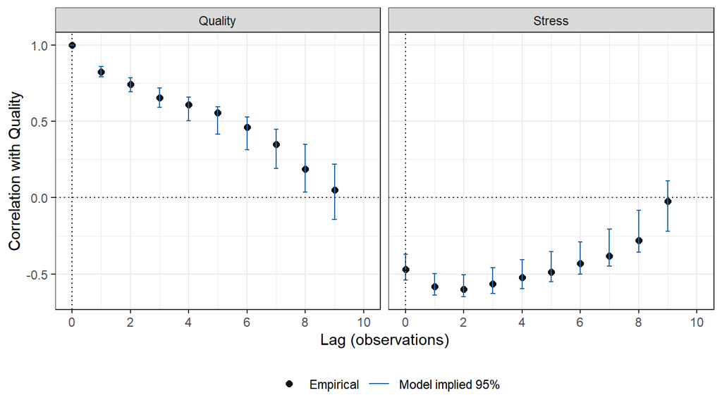

```r
ctFitCheckCov(fit)
```

`ctFitAdequacy()` tests the one-step-ahead predictions: whether the prediction errors have the mean, variance and correlations over time that the model says they should:

```r
adequacy <- ctFitAdequacy(fit)
adequacy
```

```
#> Adequacy: no family detects misfit at alpha = 0.05
#> (estimation removed by: derivative; 100 generated datasets)
#>
#>        family statistics                         worst worst_z      p p_adj
#>     residuals         16        Quality~Stress gap 1-2   1.910 0.5680     1
#>        latent         16        stress~quality gap <=1   1.890 0.6120     1
#>    volatility          8              Quality^2 gap >3  -2.430 0.0918     1
#>         pairs          1                Stress:Quality  -0.568 0.6950     1
#>      periodic         12           Quality period 2.25   1.860 0.5320     1
#>  distribution          8                  skew(Stress)  -1.980 0.9360     1
#>           fit          2            spread of unit fit  -1.140 0.9150     1
#>       effects         19                   P(u2 < 1.5)   1.230 0.9860     1
#>    dependence          4         dcor(Quality^2, past)   1.640 0.2530     1
#>      subjects          8      sd(lag1_Quality_Quality)   1.050 0.9170     1
#>     nonlinear         10 cor(dQuality,Quality*Quality)   1.690 1.0000     1
#>
#> Size of what remains (root mean square, bias-corrected; p_close tests that it is at least close):
#>                                     measure estimate lower   upper close
#>              residual correlation, all gaps   0.0110     0 0.03170  0.05
#>         residual correlation, shortest gaps   0.0000     0 0.02640  0.05
#>       latent residual correlation, all gaps   0.0000     0 0.02680  0.05
#>  latent residual correlation, shortest gaps   0.0186     0 0.04290  0.05
#>                      within-row correlation   0.0000     0 0.00688  0.05
#>   p_close
#>  6.07e-08
#>  1.72e-11
#>  4.83e-10
#>  2.31e-03
#>  0.00e+00
```

# A factor model for stress

Adding the second stress item gives stress two indicators. The loading of `Stress2` is free, and the loading of `Stress` is fixed to 1, which sets the scale of the stress process. Stable differences between people now belong to the processes rather than to each item, so they go in the continuous time intercepts (`CINT`, the intercepts of the processes, in discrete time added at each step). The measurement intercepts are fixed to zero except that of `Stress2`, which is the same for everyone:

```r
factormodel <- ctModel(type = 'dt',
  manifestNames = c('Stress', 'Stress2', 'Quality'),
  latentNames = c('stress', 'quality'),
  LAMBDA = c(
    1, 0,
    'stressLoading', 0,
    0, 1),
  CINT = c('cint_stress', 'cint_quality'),
  MANIFESTMEANS = c(0, 'mi_stress2, indvarying = FALSE', 0))
```

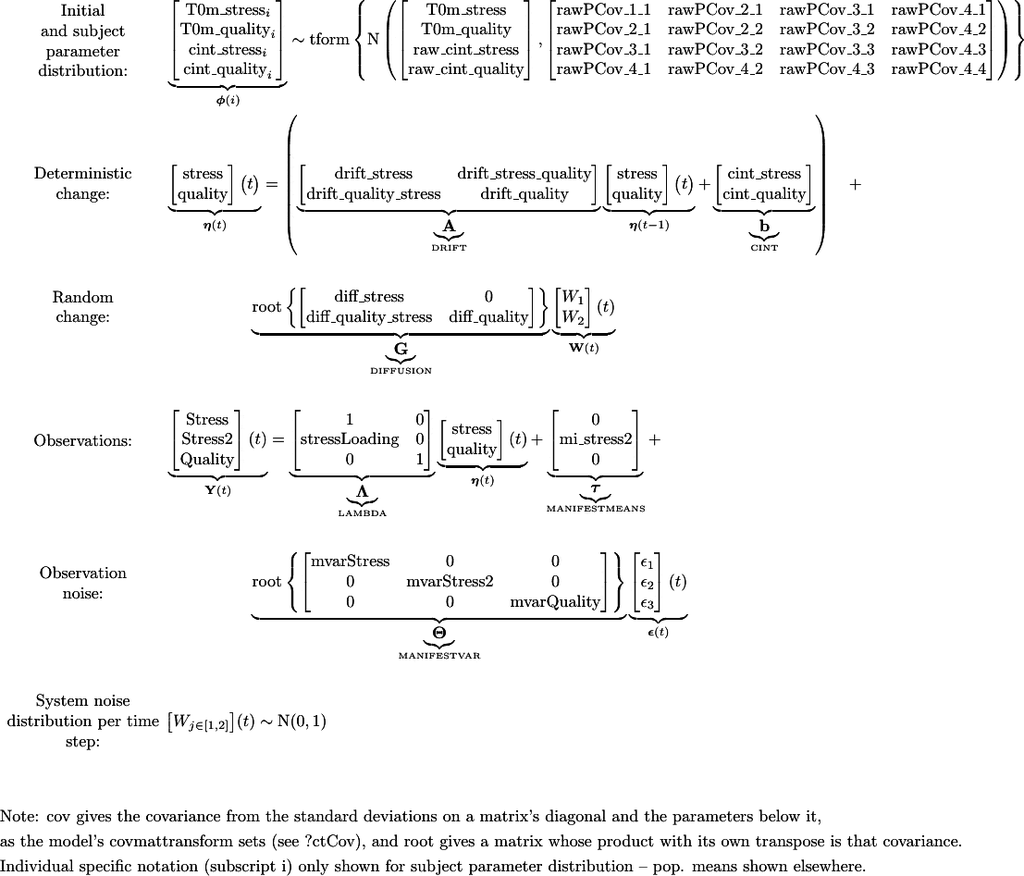

```r
factorfit <- ctFit(dat, factormodel, cores = 2)
summary(factorfit)$popmeans
```

```
#>                        mean    sd   2.5%    50%  97.5%   mode
#> T0m_stress            4.181 0.104  3.968  4.181  4.373  4.181
#> T0m_quality          -0.004 0.122 -0.230 -0.008  0.240 -0.004
#> stressLoading         0.772 0.016  0.740  0.772  0.804  0.771
#> drift_stress          0.631 0.043  0.547  0.632  0.710  0.632
#> drift_stress_quality  0.062 0.030  0.004  0.062  0.120  0.061
#> drift_quality_stress -0.283 0.028 -0.337 -0.283 -0.226 -0.284
#> drift_quality         0.693 0.024  0.645  0.693  0.738  0.691
#> diff_stress           0.820 0.029  0.767  0.819  0.877  0.821
#> diff_quality_stress   0.015 0.061 -0.109  0.015  0.130  0.014
#> diff_quality          0.505 0.045  0.424  0.503  0.596  0.503
#> mvarStress            0.461 0.028  0.409  0.460  0.517  0.460
#> mvarStress2           0.519 0.018  0.485  0.518  0.553  0.519
#> mvarQuality           0.505 0.035  0.439  0.504  0.577  0.504
#> mi_stress2            1.096 0.056  0.990  1.095  1.203  1.099
#> cint_stress           0.987 0.165  0.674  0.983  1.317  0.990
#> cint_quality          1.427 0.115  1.196  1.429  1.645  1.432
```

The loading and intercept of `Stress2` come out near the generating 0.8 and 1, and the drift near its generating values.

`ctScoreTest()` checks, without refitting, whether a parameter the model holds fixed or the same for everyone should be freed or allowed to vary:

```r
ctScoreTest(factorfit)
```

```
#> Score tests at the fitted model (laplace route, 100 subjects)
#>
#> Unmodelled heterogeneity (LM: the variance with its covariances, against an
#> equal mixture of chi-square on df - 1 and df; z: the variance alone, one sided;
#> p: the stronger of the two; sd: the one-step estimate, raw scale):
#>              parameter    LM df        z      p p_adj      sd sd_natural class
#>   drift_stress_quality 12.40  5  0.59800 0.0400 0.349 0.03690    0.03690  <NA>
#>           drift_stress 11.30  5 -2.59000 0.0685 0.349      NA         NA  <NA>
#>             mi_stress2  9.86  5 -1.50000 0.0920 0.349      NA         NA     A
#>  MANIFESTMEANS[Stress]  9.57  5 -0.46300 0.1080 0.349      NA         NA     A
#>             mvarStress  7.67  5  0.15400 0.2640 0.688 0.07040    0.06190  <NA>
#>           diff_quality  5.37  5  0.63300 0.4540 0.851 0.17200    0.16900  <NA>
#>          drift_quality  3.67  5  0.48000 0.5220 0.851 0.15200    0.06480  <NA>
#>   drift_quality_stress  1.28  5  0.04240 0.7180 0.851 0.00557    0.00557  <NA>
#>    diff_quality_stress  2.99  5 -0.06440 0.7400 0.851      NA         NA  <NA>
#>          stressLoading  2.33  5 -0.00212 0.7510 0.851 0.00238    0.01190  <NA>
#> Covariances with: T0m_stress, T0m_quality, cint_stress, cint_quality
#>
#> A new dimension of variation: largest eigenvalue 3.6, p = 0.922; direction diff_quality_stress 1, drift_quality -0.73, mvarStress -0.57, diff_quality -0.53, diff_stress 0.21
#>
#> State dependence of the drift:
#>  equation    LM df     p
#>    stress 5.830  3 0.132
#>   quality 0.196  3 0.976
#>       all 7.520  6 0.374
#>
#>             term equation       LM      p p_adj  estimate      se
#>    stress*stress   stress 4.290000 0.0384 0.231 -0.027500 0.01330
#>   stress*quality   stress 0.845000 0.3580 0.983  0.011300 0.01230
#>   stress*quality  quality 0.097700 0.7550 0.983  0.003180 0.01020
#>  quality*quality   stress 0.024800 0.8750 0.983 -0.001030 0.00654
#>  quality*quality  quality 0.001380 0.9700 0.983 -0.000239 0.00644
#>    stress*stress  quality 0.000477 0.9830 0.983        NA      NA
#>                                                                             reads
#>                                           DRIFT[stress,stress] varies with stress
#>    DRIFT[stress,stress] varies with quality, or DRIFT[stress,quality] with stress
#>  DRIFT[quality,stress] varies with quality, or DRIFT[quality,quality] with stress
#>                                         DRIFT[stress,quality] varies with quality
#>                                        DRIFT[quality,quality] varies with quality
#>                                          DRIFT[quality,stress] varies with stress
```

[output cut: 21 more lines]

```
#>   cint_stress 3.84 10 0.976
#>  cint_quality 1.88 10 0.996
#>           all 8.28 20 0.998
#>
#>                                term     LM     p p_adj estimate     se
#>        drift_quality ~ cint_quality 1.7400 0.187 0.995  -0.0300 0.0227
#>         drift_quality ~ cint_stress 1.5000 0.221 0.995   0.0358 0.0293
#>   diff_quality_stress ~ cint_stress 1.4300 0.232 0.995  -0.1540 0.1290
#>          drift_stress ~ cint_stress 1.2300 0.267 0.995  -0.1060 0.0950
#>           mvarStress2 ~ cint_stress 0.8380 0.360 0.995  -0.0299 0.0326
#>  drift_stress_quality ~ cint_stress 0.1130 0.737 0.995       NA     NA
#>            mvarStress ~ cint_stress 0.0919 0.762 0.995       NA     NA
#>          mvarQuality ~ cint_quality 0.0497 0.824 0.995       NA     NA
#>         diff_quality ~ cint_quality 0.0443 0.833 0.995       NA     NA
#>          mvarStress2 ~ cint_quality 0.0321 0.858 0.995       NA     NA
```

None of the tests is significant after adjusting for the number of tests, which is what should happen when the model is the one that generated the data. `vignette('score-tests')` explains the tests and their output.